# The Impact of Institutions on Economic Growth, Development and Poverty

https://github.com/ayenyein-thu/Thu_ENV872_EDA_FinalProject

Aye Nyein Thu

2024-12-10

## 0.1 List of Tables

- Table 2.1: Summary of Variables under Study
- Table 3.1: Descriptive Statistics

## 0.2 List of Figures

- Figure 4.1: Overview of Governance across the Countries
- Figure 4.2: Overview of Economic Freedom across the Countries
- Figure 4.3: Relation between Poverty and Governance
- Figure 4.4: Relation between Growth and Governance
- Figure 4.5: Relation bestween Development and Governance
- Figure 4.6: Relations between Development Dimensions and Economic Freedom
- Figure 4.7: Correlation Analysis between Variables
- Figure 5.1: Residuals Plot: Impact of Institutions on Poverty
- Figure 5.2: Residuals Plot: Impact of Institutions on Growth
- Figure 5.3: Residuals Plot: Impact of Institutions on Development

# 1 Rationale and Research Questions

The question of what determines the prosperity of a country has long been central to the study of development economics. While some nations have achieved high levels of development, others remain impoverished. Despite substantial progress in poverty reduction, 692 million people worldwide are still living below the $2.15 per day poverty line in 2024 (World Bank, 2024). Understanding the factors that drive prosperity could help undeveloped countries escape the poverty trap.

Several hypotheses have been developed to address the above-mentioned question of why income levels vary across countries. The 2024 Nobel laureates in economic sciences, Acemoglu and Robinson (2012), emphasized that cultural views, geographic disparities, and nations with elites and policymakers that lack knowledge on how to foster prosperity are insufficient presumptions. They assert that inclusive political and economic institutions are key drivers for sustaining growth. North (1981), another Nobel-winning institutional economist, defined intuitions as “a set of rules, compliance procedures, and moral and ethical behavioral norms designed to constrain the behavior of individuals in the interests of maximizing the wealth or utility of principals.”

Institutions are important to understand as they could shape the incentives of different economic actors in a country and influence the economic transactions (Tashtamirov, 2023). Several organizations use different indexes to quantify institutions from the aspects of rules and regulations, property rights, corruption, freedom of expression, and political rights (Lam, 2010). This study investigates how political and economic institutions impact poverty, growth, and development across 133 countries from 2000 to 2021. Using linear and fixed effects regression models, the study addresses the following research questions:

1. Does the quality of institutions reduce poverty?
2. Does the quality of institutions increase economic growth and development?
3. How does the impact of institutions on development and poverty vary when accounting for differences between countries and over time?

# 2 Dataset Information

The data required for the study are compiled from seven different secondary sources. The dependent variables are poverty headcount ratio, Gross Domestic Product (GDP) per capita, and Human Development Index (HDI), and they represent poverty, growth, and development, respectively. The two main explanatory variables are governance and economic freedom. Governance is used as a proxy for political institutions, while economic freedom serves as a proxy for economic institutions. Additional control variables include government expenditure, population size, landlocked status, and geographical area. Table 2.1 below provides a brief description of all variables utilized in the study.

Table 2.1: Summary of Variables under Study

| Variable Names | Column Names | Units | Sources | Definition |
| --- | --- | --- | --- | --- |
| Poverty Headcount | Poverty.Headcount | % of Population | World Bank’s Poverty and Inequality Platform (PIP) | % of people residing in households with consumption or income per individual falling below the international poverty threshold in 2017 |
| Human Development Index | HDI | Score ranging from 0 (lowest) to 1 (highest) | United Nations Development Programme (UNDP) | HDI is a development index that combines 3 key indicators: [1] Health by life expectany, [2]Education by total schooling years and [3] Standards of living by GNI per capita. |
| Gross Domestic Product (GDP) per capita (Constant 2015 US$) | GDP.Capita | USD | World Bank’s World Development Indicators (WDI) | GDP is the total value additions of producers residing in the nations. It adds product taxes and deducts subsidies. |
| Governance | Governance | Score ranging from -2.5 (lowest) to 2.5 (highest) | World Bank’s Worldwide Governance Indicators | Governance indicators are composed of 6 dimensions: [1] Voice and Accountability; [2] Political Stability and Absence of Violence/ Terrorism; [3] Government Effectiveness; [4] Regulatory Quality; [5] … |
| Economic Freedom | Econ.Freedom | Score ranging from 0 (lowest) to 10 (highest) | Fraser Institute (FI) | The Economic Freedom Index by Fraser Institute measures how much economic freedom a country has by using 5 different areas: [1] Size of Government; [2] Legal System and Security of Property Rights; [3… |
| Government Expenditure | Gov.Expense | % of GDP | World Bank’s World Development Indicators (WDI) | The study combines total government expenditure on education and current health expenditure to define as Government Expenditure. |
| Population | Population | No. of People | World Bank’s World Development Indicators (WDI) | Total population based on estimates of national population censuses, fertility, mortality and migration |
| Landlocked | Landlocked | 0(not landlocked) or 1 (landlocked) | CEPII | It represents the geographic condition if a country is landlocked or not. |
| Area | Area | Square kilometers | CEPII | It represents the geographic area of a country in square kilometers. |

# 3 Data Wrangling

The data assessed from various sources are first cleaned and complied in a panel data format. As described in the table, the governance indicators have six individual dimensions, which are combined into a single Governance index by calculating the row means. Similarly, for the economic freedom variables, only the aggregated “Economic Freedom” index is used to represent economic institutions. These approaches are deployed to avoid multicollinearity issues that may arise from using individual variables.

Further, health and education expenditures are are aggregated to represent government expenditures. Among different types of government expenditures, health and education are used to allow for an analysis of factors linked to long-term growth. Then, the common years for all datasets are filtered from the combined data set. Missing values are removed from the dataset rather than interpolated. This approach is chosen because interpolating missing data across different sources could introduce inaccuracies. After the data wrangling process, the final dataset covers 133 countries over the period from 2000 to 2021. Table 3.1 below provides a summary of the descriptive statistics for the key variables included in the study.

Table 3.1: Descriptive Statistics

| variable | count | mean | sd | min | max | range | se |
| --- | --- | --- | --- | --- | --- | --- | --- |
| Poverty.Headcount | 2175 | 0.12 | 0.20 | 0.00 | 0.84 | 0.84 | 0.00 |
| GDP.Capita | 2175 | 15000.35 | 20265.61 | 263.36 | 112417.88 | 112154.52 | 434.54 |
| HDI | 2175 | 0.72 | 0.17 | 0.26 | 0.96 | 0.70 | 0.00 |
| Gov.Expense | 2175 | 11.02 | 3.60 | 3.40 | 24.16 | 20.76 | 0.08 |
| Population | 2175 | 52144925.24 | 169874360.33 | 89949.00 | 1412360000.00 | 1412270051.00 | 3642488.62 |
| Area | 2175 | 955265.85 | 2431295.40 | 316.00 | 17075400.00 | 17075084.00 | 52132.45 |
| Governance | 2175 | 0.12 | 0.90 | -1.71 | 1.95 | 3.65 | 0.02 |
| Econ.Freedom | 2175 | 6.81 | 0.99 | 3.68 | 8.89 | 5.21 | 0.02 |

# 4 Exploratory Analysis

Following the summary statistics, the maps presented below illustrate the quality or strength of political and economic institutions across the countries in the study. As depicted in the figures, the institutions tend to be stronger in countries such as the United States, Canada, Australia, and many nations in Europe, while some countries in Asia and Africa exhibit considerably weaker institutions.

[interactive chart not shown]

Figure 4.1: Overview of Governance

[interactive chart not shown]

Figure 4.2: Overview of Economic Freedom

Figure 4.2 presents the economic freedom scores of the countries and they fall within 5 (lowest) and 8.5 (highest).

Subsequent to the general analysis of political and economic institutions within the countries under study, the following figures illustrate the simple linear relationships between main dependent variables and independent variables.

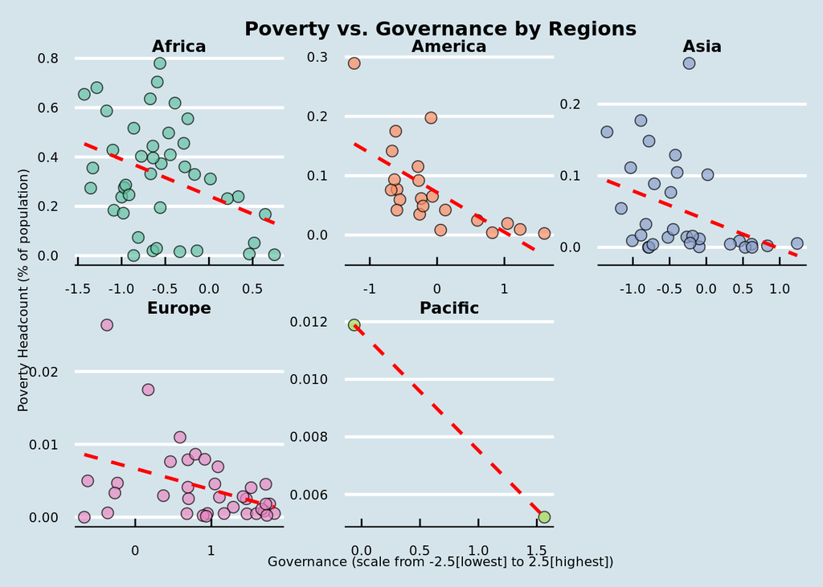

Figure 4.3: Relation between Poverty and Governance

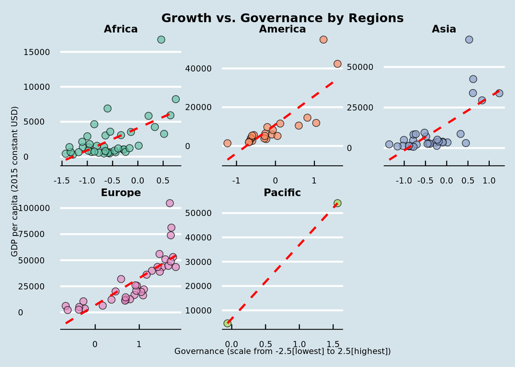

Figure 4.4: Relation between Growth and Governance

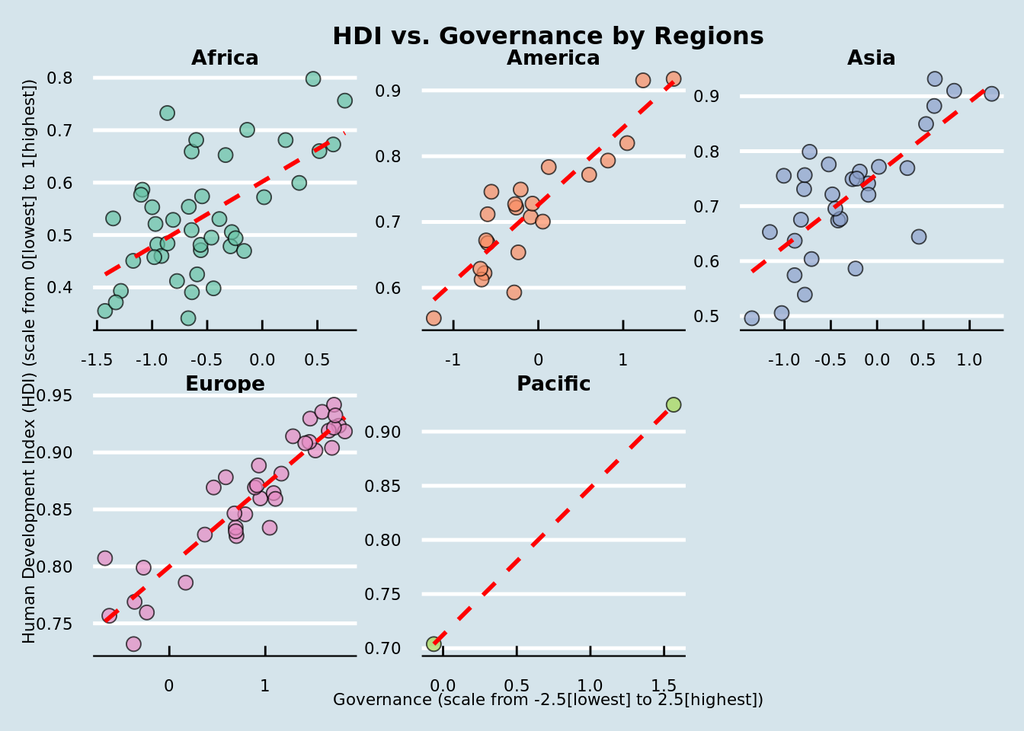

Figure 4.5: Relation between Development and Governance

When the relationships between political institutions (proxied by governance) and poverty (Figure 4.3), growth (Figure 4.4), and development (Figure 4.5) are visualized across regions, the results consistently suggest that stronger political institutions are associated with lower poverty levels and higher growth and development.

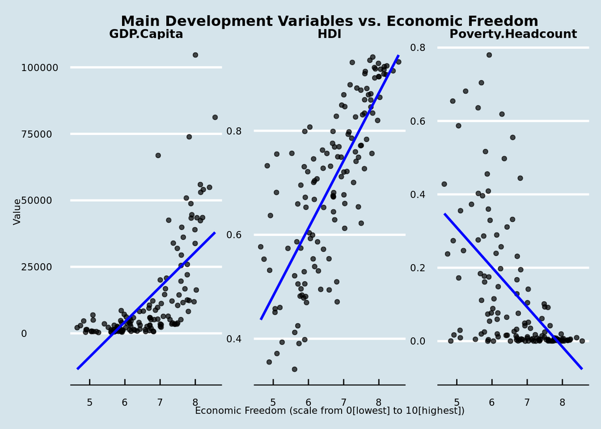

Figure 4.6: Relation between Development Dimensions and Economic Freedom

Similarly, when the dependent variables are plotted against economic institutions (represented by the Economic Freedom index), the data indicate that higher economic freedom is correlated with lower poverty rates and higher levels of growth and development (Figure 4.6).

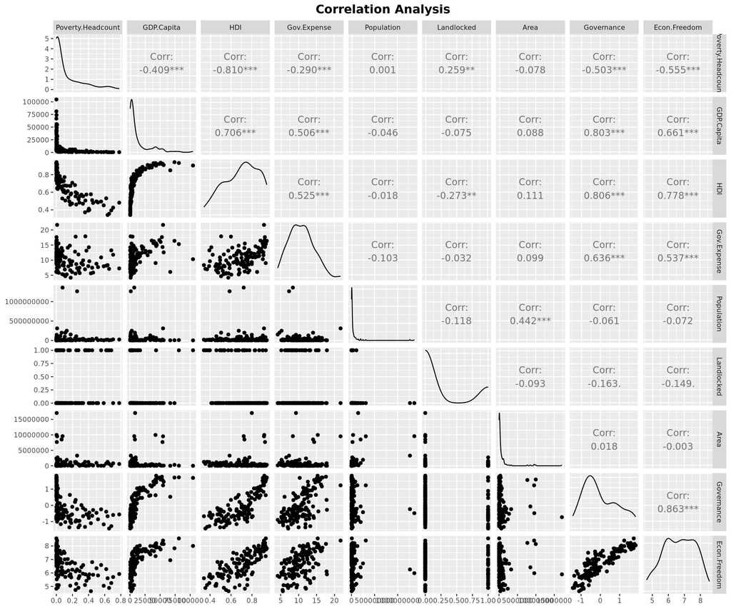

Figure 4.7: Correlation Analysis between Variables

The final plot (Figure 4.7) displays the correlation matrix of the variables included in the study. The plots and visualizations in this exploratory analysis provide an overview of political and economic institutions, as well as the correlations between key variables. The following section, Data Analysis, will apply statistical methods to evaluate the significance of these correlations and explore potential causal relationships.

# 5 Data Analysis

This study uses two statistical tools: a linear model or pooled Ordinary Least Square (OLS) model and a panel regression model. The pooled OLS model estimates the simple linear relationship between variables. However, in the institution-development setting, the OLS results can be biased and inconsistent if the effects of entities and time are present in the dataset. As noted by Studenmund (2017), fixed effects and random effects models are commonly used and are considered essential tools for panel data analysis. The fixed effects and random effects models account for unobserved heterogeneity in the data, thereby improving the estimation of the model (Wooldridge, 2010).

In this study, fixed effects and random effects regressions are conducted for each dependent variable. Then, the Hausman test is used to determine if the fixed or random effects model is more appropriate.

## 5.1 Question 1: Does the quality of institutions reduce poverty?

**Null Hypothesis 1**: Political and economic institutions do not have any effect on poverty.  
**Alternative Hypothesis 1**: Political and economic institutions have effect on poverty.

| Observations | 2175 |
| --- | --- |
| Dependent variable | Poverty.Headcount |
| Type | OLS linear regression |

| F(6,2168) | 196.343 |
| --- | --- |
| R² | 0.352 |
| Adj. R² | 0.350 |

|  | Est. | S.E. | t val. | p |
| --- | --- | --- | --- | --- |
| (Intercept) | 0.786 | 0.057 | 13.803 | 0.000 |
| lag(Gov.Expense) | -0.002 | 0.001 | -1.266 | 0.206 |
| log(Population) | -0.002 | 0.003 | -0.611 | 0.541 |
| Landlocked | 0.071 | 0.008 | 8.440 | 0.000 |
| log(Area) | 0.001 | 0.003 | 0.482 | 0.630 |
| Governance | -0.015 | 0.008 | -1.846 | 0.065 |
| Econ.Freedom | -0.095 | 0.007 | -14.305 | 0.000 |

Standard errors: OLS

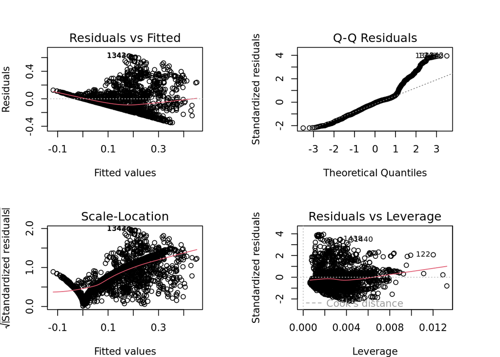

Figure 5.1: Residuals Plot: Impact of Institutions on Poverty

The results indicate that economic institutions have a positive effect on reducing the poverty headcount ratio , with the effect being statistically significant at the 99% confidence level. However, the impact of political institutions (proxied by governance) is less pronounced but still statistically significant at the 90% level.

**Variance Inflation factor (VIF) Test**

```
## lag(Gov.Expense)  log(Population)       Landlocked        log(Area)
##         1.704398         2.419847         1.089545         2.411167
##       Governance     Econ.Freedom
##         4.392063         3.691875
```

The VIF test results suggest that there is less likely to exhibit multicollinearity between variables used in the study, as all values fall below the standard VIF threshold of 5.

## 5.2 Question 2: Does the quality of institutions increase economic growth and development?

**Null Hypothesis 2a**: Political and economic institutions do not have any effect on economic growth.  
**Alternative Hypothesis 2a**: Political and economic institutions have effect on economic growth.

| Observations | 2175 |
| --- | --- |
| Dependent variable | log(GDP.Capita) |
| Type | OLS linear regression |

| F(6,2168) | 1289.459 |
| --- | --- |
| R² | 0.781 |
| Adj. R² | 0.781 |

|  | Est. | S.E. | t val. | p |
| --- | --- | --- | --- | --- |
| (Intercept) | 6.229 | 0.250 | 24.955 | 0.000 |
| lag(Gov.Expense) | 0.012 | 0.005 | 2.315 | 0.021 |
| log(Population) | -0.002 | 0.014 | -0.174 | 0.862 |
| Landlocked | -0.312 | 0.037 | -8.461 | 0.000 |
| log(Area) | 0.048 | 0.012 | 4.028 | 0.000 |
| Governance | 1.173 | 0.035 | 33.795 | 0.000 |
| Econ.Freedom | 0.248 | 0.029 | 8.563 | 0.000 |

Standard errors: OLS

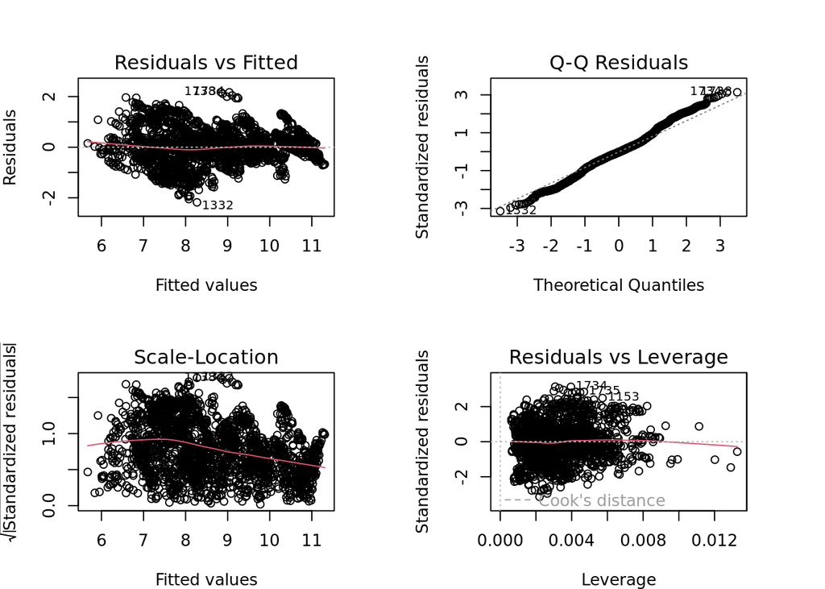

Figure 5.2: Residuals Plot: Impact of Institutions on Growth

According to the linear regression results, both governance and economic freedom are positively and significantly related to economic growth.

| Observations | 2175 |
| --- | --- |
| Dependent variable | HDI |
| Type | OLS linear regression |

| F(6,2168) | 864.186 |
| --- | --- |
| R² | 0.705 |
| Adj. R² | 0.704 |

|  | Est. | S.E. | t val. | p |
| --- | --- | --- | --- | --- |
| (Intercept) | 0.170 | 0.032 | 5.243 | 0.000 |
| lag(Gov.Expense) | 0.004 | 0.001 | 6.328 | 0.000 |
| log(Population) | 0.004 | 0.002 | 2.311 | 0.021 |
| Landlocked | -0.046 | 0.005 | -9.619 | 0.000 |
| log(Area) | 0.001 | 0.002 | 0.578 | 0.563 |
| Governance | 0.078 | 0.005 | 17.273 | 0.000 |
| Econ.Freedom | 0.062 | 0.004 | 16.366 | 0.000 |

Standard errors: OLS

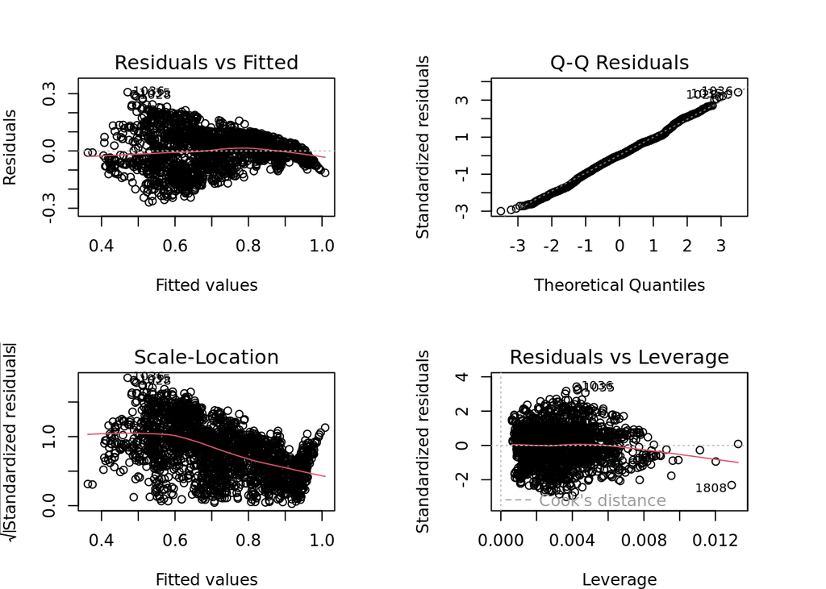

Figure 5.3: Residuals Plot: Impact of Institutions on Development

Similar to the results for economic growth, the regression analysis for economic development shows that both governance and economic freedom are positively related to development outcomes. These relationships are highly significant, with p-values below 0.001.

## 5.3 Question 3: How does the impact of institutions on development and poverty vary when accounting for differences between countries and over time?

The study employs linear regression models to answer research question 1 and 2. For question 3, the commonly used panel analysis methods, fixed effects and random effects are applied. As explained earlier, the Hausman test is conducted to decide which model to use. All the test results described below consistently indicate that the fixed effects regression is a better fit model. Therefore, the summary of the fixed effects models for all three dependent variables is presented in the below table.

```
Hausman Test
```

data: Poverty.Headcount ~ lag(Gov.Expense) + log(Population) + Landlocked + … chisq = 385.32, df = 4, p-value < 2.2e-16 alternative hypothesis: one model is inconsistent

```
Hausman Test
```

data: log(GDP.Capita) ~ lag(Gov.Expense) + log(Population) + Landlocked + … chisq = 57.81, df = 4, p-value = 0.000000000008363 alternative hypothesis: one model is inconsistent

```
Hausman Test
```

data: HDI ~ lag(Gov.Expense) + log(Population) + Landlocked + log(Area) + … chisq = 1094.7, df = 4, p-value < 2.2e-16 alternative hypothesis: one model is inconsistent

**Fixed Effects Panel Regression Model Results**

|  | *Dependent variable:* |  |  |
| --- | --- | --- | --- |
|  | Poverty.Headcount | log(GDP.Capita) | HDI |
|  | Poverty Headcount | GDP.Capita | HDI |
|  | (1) | (2) | (3) |
| lag(Gov.Expense) | -0.001 (0.001) | 0.007*** (0.002) | 0.003*** (0.0004) |
| log(Population) | -0.298*** (0.012) | 0.608*** (0.034) | 0.186*** (0.005) |
| Governance | -0.061*** (0.007) | 0.261*** (0.022) | 0.015*** (0.003) |
| Econ.Freedom | -0.019*** (0.004) | 0.140*** (0.013) | 0.021*** (0.002) |
| Observations | 1,876 | 1,876 | 1,876 |
| R<sup>2</sup> | 0.345 | 0.322 | 0.560 |
| Adjusted R<sup>2</sup> | 0.294 | 0.269 | 0.525 |
| F Statistic (df = 4; 1740) | 229.065*** | 206.326*** | 552.635*** |
| *Note:* | p<0.1; p<0.05; p<0.01 |  |  |

# 6 Summary and Conclusions

Both linear regression and fixed effects regression results highlight that political and economic institutions are significantly related to poverty, growth, and development. The relationships between institutions and both growth and development are highly significant at the 99% confidence level in both the linear and panel regression models. The association between poverty and institutions is also strong in the panel regression, though somewhat weaker in the linear regression, showing significance at the 90% level. Since the impact of institutions on poverty, growth and development are significant in both statistical methods, it exhibits a certain level of robustness. These findings align with the claims of institutional economists, including the 2024 Nobel winners: Daron Acemoglu, Simon Henry Roberts Johnson, and James A. Robinson, who underscores the importance of inclusive institutions in shaping long-term development outcomes.

This study therefore reaffirms the argument that high-quality institutions could enhance the likelihood of promoting economic growth, development and poverty reduction. The study thereby highlights the importance of developing policies that strengthen both political and economic institutions. Developing countries should focus on fostering institutions by combating corruption, ensuring political stability and low level of violence, enhancing public accountability, promoting regulatory environment, and safeguarding property rights.

While presenting the significance of institutions, this study also acknowledges general criticisms on the impact of institutions. Some of these include the complexity of measuring institutions, with current indexes unable to fully capture; the multi-faceted nature of development, where institutions are only one of many influencing factors; and potential endogeneity issues.

The study relies on relatively simple statistical tools to estimate the impact of political and economic institutions on poverty, growth, and development. For the further studies, it is suggested to use advanced tools such as the Instrumental Variables (IV)/Two-Stage Least Squares (2SLS) model, the Generalized Method of Moments (GMM), Granger Causality, and nonlinear models to enhance estimation.

# 7 References

1. Acemoglu, D., & Robinson, J. A. (2012). Why nations fail: the origins of power, prosperity and poverty. Random House.
2. Lam, K. Y. (2011). Institutions and economic development (Doctoral dissertation, University of Birmingham). https://etheses.bham.ac.uk/id/eprint/1331/1/Lam11PhD.pdf
3. North, D. C. (1981). Structure and Change in Economic History. New York: Norton and Co.
4. Studenmund, A. H. (2017). A practical guide to using econometrics. Pearson Higher Education.
5. Tashtamirov, M. (2023). The Role of Institutions in Economic Development and Their Impact on Economic Growth in Different Countries. In SHS Web of Conferences (Vol. 172, p. 02005). EDP Sciences. https://doi.org/10.1051/shsconf/202317202005
6. Wooldridge, J. M. (2010). Econometric analysis of cross section and panel data. MIT Press.
7. World Bank. (2024). Poverty and Inequality Platform (PIP) Platform. Retrieved on 8th December 2024, https://pip.worldbank.org/home